# bis620

```r
library(bis620.2022)
```

## Team Members

- Lang Ding (ld698)
- Shurui Wang (sw2349)

## Background and motivation

### Data Description

The dataset comes from the NCT00364013 study on clinicaltrials.gov named ‘[PRIME: Panitumumab Randomized Trial In Combination With Chemotherapy for Metastatic Colorectal Cancer to Determine Efficacy](https://clinicaltrials.gov/ct2/show/NCT00364013)’ This study was to assess whether panitumumab in combination with FOLFOX chemotherapy improves PFS compared to FOLFOX alone as first-line therapy for mCRC among subjects with wild-type KRAS tumors and subjects with mutant KRAS tumors. The dataset contains 7 tables, which are `adae`, `adlb`, `adls`, `adpm`, `adrsp`, `adsl`, and `biomark`. In our final project, since we are focusing on the adverse effect and the new lesion for the patients before or after treatment, we are only going to use 3 of the 7 tables. Each row of each table represents a record for a patient with a corresponding `SUBJID`.

- adsl  
  This table has 935 rows and 19 columns. It records each patient’s basic information(age, sex, weight, etc.), primary tumor type, and treatment.
- adae  
  This table has 3211 rows and 7 columns. It records each patient’s adverse events type, System Organ Class(where adverse events happen), severity grade, and whether this is a continuing event.
- adls  
  This table has 29118 rows and 11 columns. It records each patient’s visit day and information on any new lesions they have reported on that day, along with the reader’s information.

### Motivation

As we examined the dataset, we found that, during the treatment of the selected chemotherapy, new lesions or adverse events might occur to an individual. The occurrence of both two might result from the natural course of cancer or the toxicity of the chosen chemotherapy. However, the association between them is unknown. During the treatment, lesion diagnosis might be more expensive than detecting adverse events in participants. Therefore, we would like to investigate the potential association between the adverse event and lesion to know if the occurrence of an adverse event might indicate possible lesions when using the chosen chemotherapy in this clinical trial.

## Research question

In this study, instead of choosing the actual name of adverse events, we choose the variable of the location where adverse events happened, which is called “System Organ Class”. We think that the adverse events happened in the system organ class of “Skin and subcutaneous tissue disorders” and the lesion in the liver might be associated with the toxicity of the chosen chemotherapy since the liver is a crucial organ to process poisons in the body, and the skin system with active cell division activity is susceptible to the nature of chemotherapy that suppresses this activity. As a result, we would like to investigate if there exists an association between them. Therefore, We hypothesized that **a patient in the study who has a higher level of “Skin and subcutaneous tissue disorders” adverse effect would have a higher chance of getting new lesions on a specific site during the treatment.**

## Data cleaning and exploration

### Data cleaning

- Joining the table

Since our research question is about patients with “Skin and subcutaneous tissue disorders” adverse effects, and we want to see the variation in different severity levels, we filtered the `adae` table with AESOC = “Skin and subcutaneous tissue disorders”, and dropped missing values in `AESEVCD`(severity levels). Then, we joined adae with adsl and adls table, by patients’ `SUBJID`. This new dataset is saved as `lesion`.

- `LSSITE`

There were 1505 NA and 601 empty values in the LSSITE column in `lesion` dataset after joining the above three tables. This is because not all patients have a new lesion. We have replaced them with “None” before saving the .rda file and the resulting lesion data has no missing values.

```r
devtools::load_all()
```

```
#> ℹ Loading bis620.2022
```

```r
data(lesion)
print(sum(is.na(lesion$LSSITE)))
```

```
#> [1] 0
```

```r
print(sum(lesion$LSSITE == ""))
```

```
#> [1] 0
```

### Data preprocessing

The data preprocessing steps are done in the data_processing() function. The user can input a specific LSSITE name they want to check along with the lesion data to the function, and get processed lesion data with 2 new columns added. The first added column is `new_ls`, which has two categories: the specific user input LSSITE, and `Other`. The second added column is `level`, which transferred the `AESEVCD` column into 2 categories. `level` = ‘LOW’ when `AESEVCD` = 1, and `level` = ‘HIGH’ for `AESEVCD` = 2, 3, or 4. After data preprocessing we should be able to check the variation in different `LSSITE` values. For example, if we want to check the lesion on the liver, we could preprocess the data with the following command: `data_processing(lesion, "Liver")`.

### Data Exploration

There are two treatment groups in this study. We consider “FOLFOX alone” as the control group and “Panitumumab + FOLFOX” as the treatment group.

Since we would like to investigate the potential association between the adverse effect and the site of lesion occurred in the course of the clinical trial, we made the summary table as follows:

```
                           Blood and lymphatic system disorders
                                                              2
                                     Gastrointestinal disorders
                                                              1
           General disorders and administration site conditions
                                                             26
                                        Hepatobiliary disorders
                                                              9
                                    Infections and infestations
                                                            166
                 Injury, poisoning and procedural complications
                                                             23
                    Neoplasms benign, malignant and unspecified
                                                              8
                       Reproductive system and breast disorders
                                                              1
                Respiratory, thoracic and mediastinal disorders
                                                              1
                         Skin and subcutaneous tissue disorders
                                                           2929
                                             Vascular disorders
                                                             45
```

Because the majority type of adverse effect is “Skin and subcutaneous tissue disorders”, we think that it would be interesting to examine the association between the location of lesion and the occurrence of “Skin and subcutaneous tissue disorders”. The following is the summary of total counts of lesion sites that have occurred during this clinical trial.

| LSSITE | Freq |
| --- | --- |
| Abdomen | 3626 |
| Bone | 365 |
| Central Nervous System | 16 |
| Chest | 218 |
| Gastrointestinal | 3095 |
| HEENT/Neck | 1 |
| Liver | 61724 |
| Lymph Nodes | 21726 |
| Musculoskeletal | 210 |
| None | 2106 |
| Other | 381 |
| Pelvic Site | 1547 |
| Pulmonary | 7561 |
| Skin | 208 |
| Spleen | 161 |

As we can see, it is very rare that lesions occurred in HENNT/Neck in this clinical trial. However, lesions that occur are usually found in sites like “Liver” and “Lymph Nodes”. Therefore, in the following steps, we use plots and run tests to examine whether there is a significant difference of the number of lesion occurrence on a specific site within the control group (FOLDOX alone) and the experiment group (Panitumumab + FOLFOX).

In the following, given a specific lesion site, we used the function `plot_lesion` to graph a side-by-side bar plot facet-wrapped by treatment (ATRT) and level of the “Skin and subcutaneous tissue disorders” adverse effect to check and compare the number of lesion found on this specific site.

We checked bat plots for all lesion sites to see if the ratio between the number of lesion occurred on this site is roughly different due to the level of “Skin and subcutaneous tissue disorders”.

**Similar Ratio**

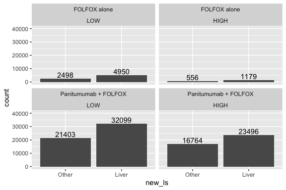

```r
plot_lesion(lesion, "Liver")
```

This is the bar plot to check the number of lesions occurred on “Liver”. As we can see, in both of the control group and treatment group, proportion of number of lesion occurred in “Liver” does not change from LOW level “Skin and subcutaneous tissue disorders” to HIGH level “Skin and subcutaneous tissue disorders”. In the control group, the proportion of lesion occurred on “Liver” is around 67% of the total number of lesion occurred. In the experimental group, the proportion of lesion occurred on “Liver” is around 60% of the total number of lesion occurred. Therefore, the number of lesions that occur on “Liver” does not seem to be affected by the level of “Skin and subcutaneous tissue disorders” adverse effect.

**Ratio Changed**

[figure not shown]

```r
plot_lesion(lesion, "Pulmonary")
```

## Interpretation and conclusions